# Playing Around With Survival Analysis - 2

## Objective:

1. Find out effect of covariates on hazard ratio without making any assumption about the shape of the hazard function.
2. Interpret the model outputs. Evaluate model summary, coefficient significance.
3. Validate proportional hazards assumption.

## Solution:

This can be done using Cox Propotional Hazard model. (No time-varying covariates)

`survival` package has `coxph` function to accomplish this.

1. `Surv` function to get the data in the right format, incorporating censoring information.
2. which will then be passed to `coxph` function alongwith the covariate(s) to find out their effect.
3. `cox.zph` to validate proportional hazard assumption.

## Code:

```r
library(magrittr)
{
  library(OIsurv)
  library(dplyr)
  library(broom)
  library(ggplot2)
  library(survsim)
}
# %>%
#   suppressMessages()
```

```r
# Real dataset from KMsurv package
data(tongue)
# head(tongue)
# summary(tongue)
# help(tongue)
```

This dataset is about 80 male subjects who were diagnosed with one of the 2 types of cancer of the tongue. Time tp death is expressed in weeks. More info on this can be found from the package documentation for this dataset using `help(tongue)`.

Shown below is `coxph` model with cancer `type` as covariate.

```r
# COX PH
tongue_coxph = coxph(Surv(time = time, event = delta) ~ as.factor(type), data = tongue)
tongue_coxph_tidy = tidy(tongue_coxph)
tongue_coxph_tidy # equivalent of print()
```

```
##               term  estimate std.error statistic    p.value    conf.low
## 1 as.factor(type)2 0.4663742 0.2804476  1.662964 0.09631971 -0.08329303
##   conf.high
## 1  1.016041
```

- The confidence interval for the coefficient estimate [-0.083293, 1.0160414] contains 0, implies the relationship is not significant.
- The likelihood ratio test against the null model (below) has p-value of 0.1020272 which again supports this.

```r
glance(tongue_coxph) # equivalent of summary()
```

```
##    n nevent statistic.log p.value.log statistic.sc p.value.sc
## 1 80     53      2.673567   0.1020272     2.814338 0.09342544
##   statistic.wald p.value.wald  r.squared r.squared.max concordance
## 1           2.77   0.09631971 0.03286732     0.9929755   0.5642941
##   std.error.concordance    logLik     AIC  BIC
## 1            0.03561883 -196.9975 395.995 -Inf
```

```r
# plot(survfit(tongue_coxph, newdata = as.data.frame(cbind(type = 1)))) # for prediction, only the inputs/covariates need to be provided
```

Now, even though the coefficient is not significant, we can test and see if the model assumptions are satisfied.

```r
# Validating Cox PH Assumptions
validate_coxph = cox.zph(tongue_coxph, transform = "km")
validate_coxph
```

```
##                      rho chisq     p
## as.factor(type)2 -0.0958 0.473 0.491
```

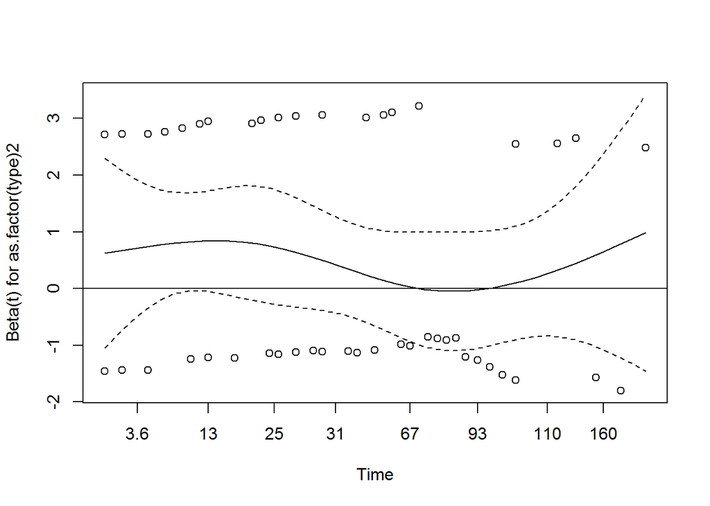

```r
plot(validate_coxph)
abline(h=0)
```

```r
validate_gg = data.frame(cbind(x = validate_coxph[["x"]],
                               y = validate_coxph[["y"]]))
```

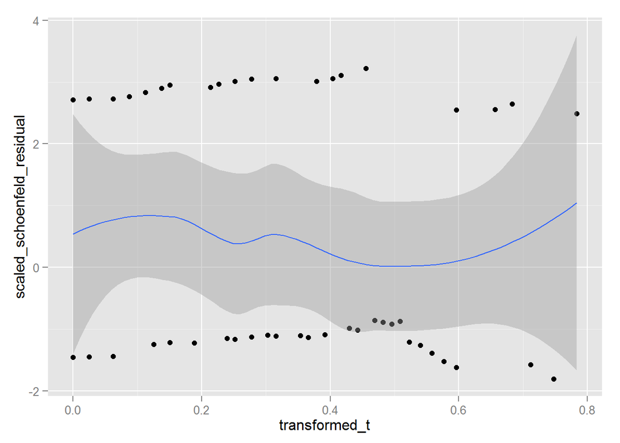

```r
names(validate_gg) = c("transformed_t", "scaled_schoenfeld_residual")

ggplot(data = validate_gg, aes(x = transformed_t, y = scaled_schoenfeld_residual)) +
  geom_point() +
  geom_smooth(method = "loess")
```

### Simulating a dataset using `simple.surv.sim` function from `survsim` package.

(The same dataset was used in [prior post](http://justanotherdatablog.blogspot.com/2015/08/survival-analysis-1.html))

- **Time-to-event:** Assumed to be following weibull distribution with p = 1.5 i.e. the mode of the time to event is closer to median then for exponential distribution (p = 1). Exponential distribution has it’s mode at 0, as we increase p, the mode moves to the right.
- **Time-to-censoring:** Assumed to be following weibull distribution with p = 10 i.e. censoring is happening mostly in the latter part of the survival curve.
- **Covariate:** 1 Binary covariate with p = .7 and beta of 0.6. (In the following post I’ll try to reverse-engineer this beta using `coxph` or other similar models)

Following is the same analysis using this simulated dataset. Try and see if you can make sense of code and the output.

```r
set.seed(2365)
d1 = simple.surv.sim(# event dist - weibull with p = 1.5
  n = 500, foltime = 1000, dist.ev = 'weibull', anc.ev = 1.5, beta0.ev = 2,
  # censoring dist - weibull with p = 10
  dist.cens = 'weibull', anc.cens = 10, beta0.cens = 2.01,
  # 1 binary covariate
  beta = list(c(.6)), x = list(c("bern", .7))
                     )
# View(d1)

# summary(d1)
summary(as.data.frame(d1))
```

```
##       nid            status          start        stop              z
##  Min.   :  1.0   Min.   :0.000   Min.   :0   Min.   :0.1452   Min.   :1
##  1st Qu.:125.8   1st Qu.:0.000   1st Qu.:0   1st Qu.:4.8752   1st Qu.:1
##  Median :250.5   Median :0.000   Median :0   Median :6.6124   Median :1
##  Mean   :250.5   Mean   :0.372   Mean   :0   Mean   :5.9297   Mean   :1
##  3rd Qu.:375.2   3rd Qu.:1.000   3rd Qu.:0   3rd Qu.:7.4102   3rd Qu.:1
##  Max.   :500.0   Max.   :1.000   Max.   :0   Max.   :9.1243   Max.   :1
##        x
##  Min.   :0.000
##  1st Qu.:0.000
##  Median :1.000
##  Mean   :0.714
##  3rd Qu.:1.000
##  Max.   :1.000
```

```r
# COX PH
d1_coxph = coxph(Surv(time = start, time2 = stop, event = status) ~ as.factor(x), data = d1)
d1_coxph_tidy = tidy(d1_coxph)
d1_coxph_tidy # equivalent of print()
```

```
##            term   estimate std.error statistic      p.value  conf.low
## 1 as.factor(x)1 -0.8220694 0.1486678 -5.529572 3.210132e-08 -1.113453
##    conf.high
## 1 -0.5306858
```

```r
glance(d1_coxph) # equivalent of summary()
```

```
##     n nevent statistic.log  p.value.log statistic.sc   p.value.sc
## 1 500    186      28.63993 8.716611e-08     32.31914 1.308183e-08
##   statistic.wald p.value.wald  r.squared r.squared.max concordance
## 1          30.58 3.210132e-08 0.05567025     0.9871835   0.5959589
##   std.error.concordance    logLik     AIC  BIC
## 1            0.01658598 -1074.935 2151.87 -Inf
```

```r
# plot(survfit(d1_coxph, newdata = as.data.frame(cbind(type = 1)))) # for prediction, only the inputs/covariates need to be provided
```

The coefficient for covariate `x` is significant but is -0.8220694, quiet different from the parameter we used to simulate this data i.e. `0.6`. This is happening partly due to the fact that for `coxph` we are finding the coefficients using partial likelihood without making any assumptions around the time-to-event distribution.

```r
# Validating Cox PH Assumptions
validate_d1_coxph = cox.zph(d1_coxph, transform = "km")
validate_d1_coxph
```

```
##                  rho chisq     p
## as.factor(x)1 0.0659 0.798 0.372
```

The scaled Schoenfeld residuals plot below also looks flat for the most part, seems to be increasing for higher values of time.

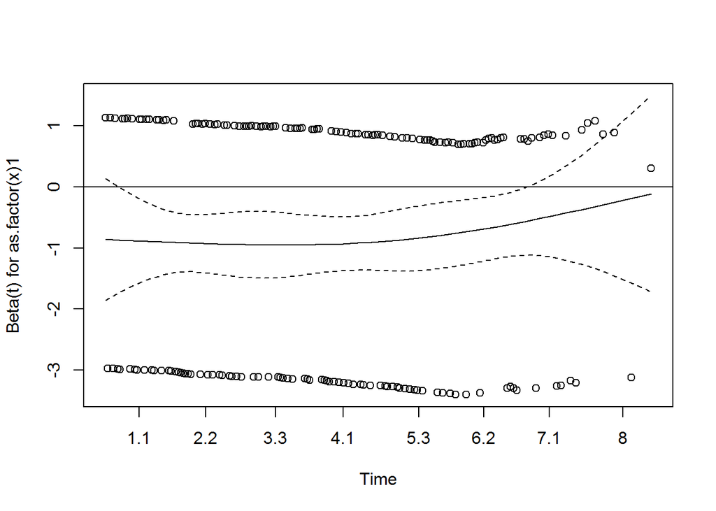

```r
plot(validate_d1_coxph)
abline(h=0)
```

Below is a ggplot2 version using `loess` fit telling the same story.

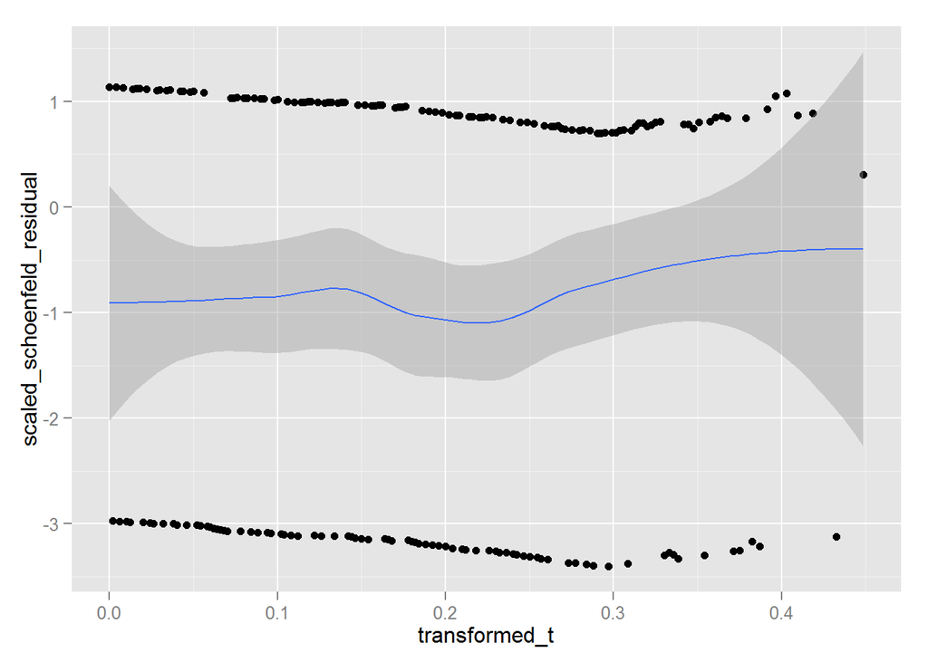

```r
validate_d1_gg = data.frame(cbind(x = validate_d1_coxph[["x"]],
                               y = validate_d1_coxph[["y"]]))
names(validate_d1_gg) = c("transformed_t", "scaled_schoenfeld_residual")

ggplot(data = validate_d1_gg, aes(x = transformed_t, y = scaled_schoenfeld_residual)) +
  geom_point() +
  geom_smooth(method = "loess")
```

## References:

- http://anson.ucdavis.edu/~hiwang/teaching/10fall/R_tutorial%201.pdf
- http://www.utstat.utoronto.ca/reid/sta442f/2009/fox-survival.pdf
- http://www.jstatsoft.org/v59/i02/paper
- http://psfaculty.ucdavis.edu/bsjjones/coxslides2.pdf